# tech_report

Shen Yan

2023-12-18

## Set up

We install the necessary packages used for the our technical report. $source.R$ includes the functions to compute the talents. $baseball\_simu.RData$ includes baseball statistics used for the examples.

## Simulation for Theorem 3.2

### System Inclusion Function Selects the Top Components From the Population

In this simulation, we first randomly generate two groups of observation: $Y_1$ and $Y_2$ from the standard normal distribution, and the number of each group is given by $n_1$ and $n_2$. Based on our setting, we assume the latent aptitudes follow the Pareto distribution with $\alpha = 1.16$. Then we obtain the latent aptitudes for each group and check whether the paradox happens. We assume the $j = k = 1$. We repeat this process 1000 times and record the frequency of the paradox. 10 Monte Carlo iterations of our simulation are performed and we compute the average of the frequency.

|  | Prob from Theorem 3.2 | Prob from simulation |
| --- | --- | --- |
| n_1 = 40, n_2 = 60, N_1 = 1e3, N_2 = 1e3 | 0.1495 | 0.1431 |
| n_1 = 30, n_2 = 70, N_1 = 1e3, N_2 = 1e3 | 0.2866 | 0.2824 |
| n_1 = 60, n_2 = 40, N_1 = 1e3, N_2 = 1e3 | 0.0000 | 0.0000 |
| n_1 = 70, n_2 = 30, N_1 = 1e3, N_2 = 1e3 | 0.0000 | 0.0000 |

### System Inclusion Function Selects the Bottom Components From the Population

In this simulation, we first randomly generate two groups of observation: $Y_1$ and $Y_2$ from the standard normal distribution, and the number of each group is given by $n_1$ and $n_2$. Based on our setting, we assume the latent aptitudes follow the Pareto distribution with $\alpha = 1.16$. Then we obtain the latent aptitudes for each group and check whether the paradox happens. We assume the $j = k = 1$. We repeat this process 1000 times and record the frequency of the paradox. 10 Monte Carlo iterations of our simulation are performed and we compute the average of the frequency.

|  | Prob from Theorem 3.2 | Prob from simulation |
| --- | --- | --- |
| n_1 = 40, n_2 = 60, N_1 = 1e3, N_2 = 1e3 | 0.0000 | 0.0000 |
| n_1 = 30, n_2 = 70, N_1 = 1e3, N_2 = 1e3 | 0.0000 | 0.0000 |
| n_1 = 60, n_2 = 40, N_1 = 1e3, N_2 = 1e3 | 0.1522 | 0.1512 |
| n_1 = 70, n_2 = 30, N_1 = 1e3, N_2 = 1e3 | 0.2893 | 0.2888 |

## Simulation for the Uniform Distribution Example

In this simulation, we verify the uniform example with a Monte Carlo simulation. In each simulation, we first randomly generate two groups of observation: $Y_1$ and $Y_2$ from the standard uniform distribution, and the number of each group is given by $n_1$ and $n_2$. Based on our setting, we assume the latent aptitudes follow the Pareto distribution with $\alpha = 1.16$ and the $\delta = 0.001$. Then we obtain the latent aptitudes for each group and check whether the paradox happens. We repeat this process 1000 times and record the frequency of the Gould paradox happening. 100 Monte Carlo iterations of our simulation are performed and we calculate the average of the frequency divided by 1000 as the probability of the Gould paradox happening.

|  | Prob from Uniform Example | Prob from simulation |
| --- | --- | --- |
| n_1 = 40, n_2 = 60, N_1 = 1e5, N_2 = 1e5 | 0.1245 | 0.123445 |
| n_1 = 30, n_2 = 70, N_1 = 1e5, N_2 = 1e5 | 0.2213 | 0.219125 |
| n_1 = 60, n_2 = 40, N_1 = 1e5, N_2 = 1e5 | 0.0000 | 0.002320 |
| n_1 = 70, n_2 = 30, N_1 = 1e5, N_2 = 1e5 | 0.0000 | 0.000715 |

## Simulation the Normal Distribution Example

In this simulation, we verify the normal example with a Monte Carlo simulation. In each simulation, we first randomly generate two groups of observation: $Y_1$ and $Y_2$ from the normal distribution with $\mu_1 = -1$ and $\mu_2 = 1$, and the number of each group is given by $n_1$ and $n_2$. Based on our setting, we assume the latent aptitudes follow the Pareto distribution with $\alpha = 1.16$, $N_1 = 1e5$ and $N_2 = 2e5$. Then we obtain the latent aptitudes for each group and check whether the paradox happens. We repeat this process 1000 times and record the frequency of the Gould paradox happening. 1000 Monte Carlo iterations of our simulation are performed and we calculate the average of the frequency divided by 1000 as the probability of the Gould paradox happening. Next, using the procedure in (Mi et al. 2009), we calculate the probability of our outcome, which involves the probability of a multivariate normal distribution.

|  | Prob from Normal Example | Prob from simulation |
| --- | --- | --- |
| sigma1 = 2, sigma2 = 4, n_1 = 40, n_2 = 60 | 0.3338 | 0.33428 |
| sigma1 = 2, sigma2 = 4, n_1 = 30, n_2 = 70 | 0.3336 | 0.33424 |
| sigma1 = 2, sigma2 = 4, n_1 = 10, n_2 = 100 | 0.3331 | 0.33346 |
| sigma1 = 2, sigma2 = 4, n_1 = 100, n_2 = 10 | 0.2378 | 0.23835 |
| sigma1 = 1, sigma2 = 1, n_1 = 40, n_2 = 60 | 0.3321 | 0.32975 |
| sigma1 = 1, sigma2 = 1, n_1 = 30, n_2 = 70 | 0.3313 | 0.33254 |
| sigma1 = 1, sigma2 = 1, n_1 = 10, n_2 = 100 | 0.3334 | 0.33351 |
| sigma1 = 1, sigma2 = 1, n_1 = 100, n_2 = 10 | 0.2593 | 0.25747 |

## Simulation of Students in Different Educational Stages

In this simulation, we simulate the process of students moving on to the next level of education from primary school to the university in an ideal setting. We consider the student’s achievement as the only criterion for school admission. First, we randomly generate 1 million talents from Pareto distribution, which corresponds to the 1 million talents of primary school students. Then we randomly generate 2 thousand school indices from 1 to 2000 and assign them to the students we generated before, which represent the schools that the students will attend. Finally, we transform ordered talents corresponding to the eligible population to percentiles from the ordered statistics and convert percentiles to ordered scores from a normal distribution, which could represent the scores the students achieve in the schools.

The final step can be described in the following formula:

$$\begin{equation} \label{eq:estiY}
Y_{i,(j)} = F_{Y_{i}}^{-1} \left( F_{X_{i}}\left(X_{i, (500*(i-1) + j))}
\right) \right)
\end{equation}$$

$$\begin{aligned}
F_{X_i}\left(X_{i,(j)} \right) & \sim U_{i,(j)},
F_{X_{i,(j)}}\left(X_{i,(j)} \right) & \sim U_{i,j}
\end{aligned}$$

where

$\sim$ means distributed as, $U_{i,j} \sim U(0,1)$, and $U_{i,(j)} \sim \operatorname{Beta}(j, n+1-j)$, n is the sample size. $X_{i, (j)}$ is the jth ordered talent in the ith school. $F_{X_{i}}$ is the cumulative distribution function of talents in the ith school. $Y_{i, (j)}$ is the jth ordered score in the ith school. $F_{Y_{i}}$ is the cumulative distribution function of scores in the ith school.

The score distribution for each school follows the Normal distribution with different parameters. We assume the mean of the Normal distribution ranges from 60 to 80 with equal space, which indicates the different levels of schools. Better schools have higher mean scores. The standard deviation for the two cases below are 2 and 5.

Students who achieve in the top 500 will advance to the next level of the best school, then students who achieve in the top 501 to 1000 will advance to the next level of the 2nd best school, and the same with the rest.50 Monte Carlo iterations of our simulation are performed.

The tendencies of the most talented students in each of the 50 simulations are displayed in the following figures. The primary_index0 in the x-axis indicates the initial schools for the students with the highest talent. The levels of schools are represented by the index on the y-axis, which goes from 1 to 2000. High-achieving schools are a sign of superiority. The following are the schools that students will attend: primary_index1 through primary_index3. It is evident that even if gifted children begin their education at a lesser school, they may advance to a top institution within two to three stages.

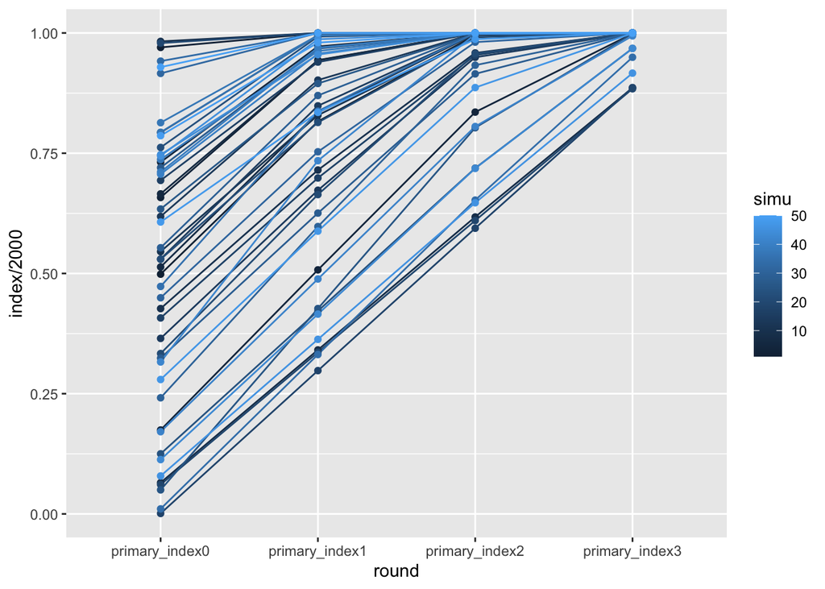

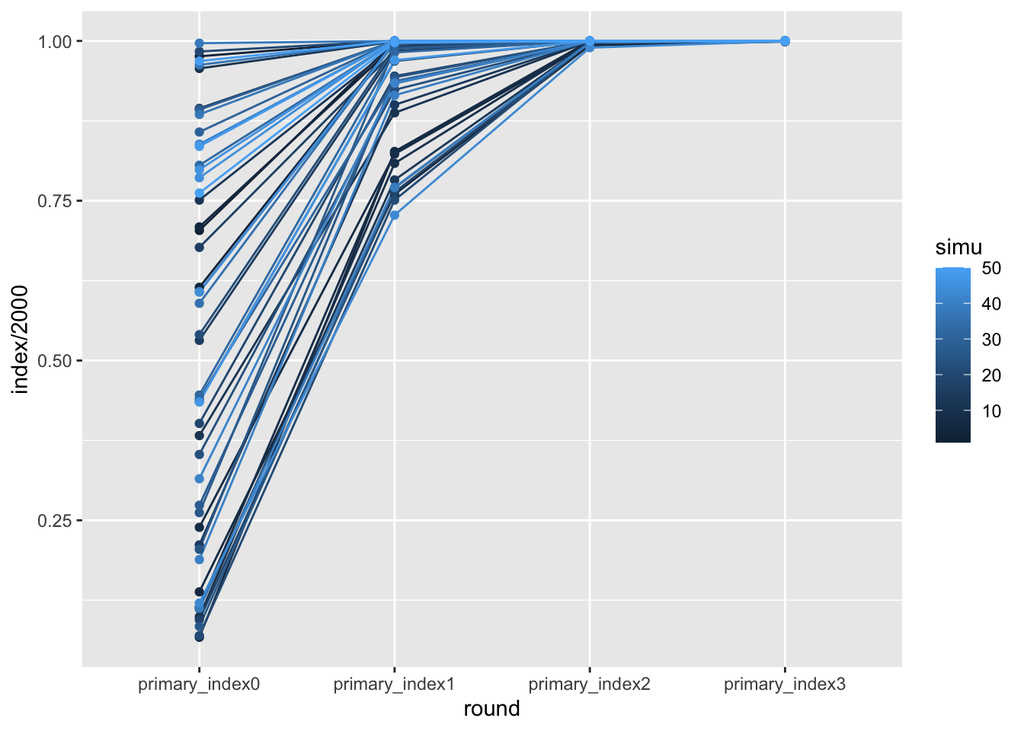

We also run 200 Monte Carlo iterations of our simulation to show the tendencies of the most talented students when they start their education career at 50%, 25%, and 0% of the schools. The score distribution for each school follows the Normal distribution with different parameters. We assume the mean of the Normal distribution ranges from 60 to 80 with equal space, and the standard deviation is set to be 2 for every school.

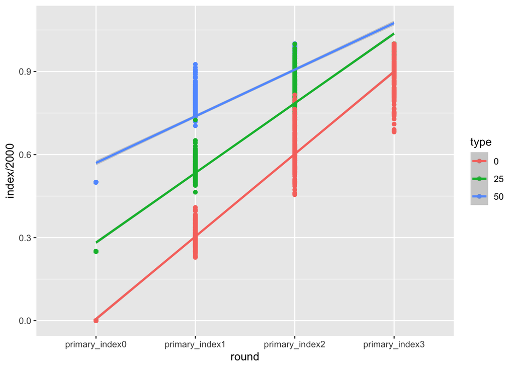

## System Inclusion Function Example in Major League Baseball

Ted Williams and Bob Feller were two of the many great baseball players who fought in the Army during World War II(WWII) . As a result, in the absence of these talented players, the players who continued in the league produced high-standard performances, such as Hal Newhouser. Now we are interested in the performance of those who played in the league during WWII (World War II) if WWII hadn’t occurred the players who served in the war would still be playing. For example, we are interested in the bWAR (Baseball-Reference Win Above Replacement) of Dizzy Trout if Bob Feller were playing in the 1944 season. In fact, Bob Feller served in the Army during WWII and he was a superior pitcher compared to Dizzy Trout.

The table below displays the performance of Spud Chandler, Dizzy Trout, and Hal Newhouser when the top talented players served in the Army or not. We assume only two pitchers would outperform Spud Chandler in the 1943 season, Dizzy Trout in the 1944 season, and Hal Newhouser in the 1945 season, which indicates the system inclusion function will not select the top $n_i$ players. Instead, under this scenario, the system inclusion function selects the 3rd best pitcher to the $(n_i + 2)$th pitchers. The details about computing the talents and estimated bWAR can be found in (Eck 2020).

Additionally, we exclude the WWII correction for the MLB-eligible population when the top talented players did not serve in the Army. The details about applying WWII correction for the MLB-eligible population can be found in (Eck 2020).

| player | served | estimated_bWAR |
| --- | --- | --- |
| Spud Chandler | Yes | 7.85 |
| Spud Chandler | No | 6.19 |
| Dizzy Trout | Yes | 8.53 |
| Dizzy Trout | No | 7.48 |
| Hal Newhouser | Yes | 11.38 |
| Hal Newhouser | No | 8.10 |

## Gould Paradox in Major League Baseball

In this analysis, we compute the probability of the paradox using the results from the Normal distribution example above and illustrate it in the application of Major League Baseball (MLB) since it is widely acknowledged that the batting average follows Normal distribution.

Specifically, we compute the probability that the top batting average in 2023 is lower than the top batting average in the other season, but the players who have the highest batting average in 2023 are more talented than those who have the highest batting average in the other season.

In this analysis, we detail the considerations made for the batting average statistics that we era-adjust using the Full House Model (Eck 2020). Park factor adjustment is considered in this analysis and we apply the adjusted park index from (Schell 2016) to all ballparks from the 1871 season to the 2022 season. The batting average can be affected by the ballpark and we apply the park factor adjustment to this statistic, which accounts for the handedness of batters.

The Full House Model will only be applied to the statistics obtained by full-time players. We define the full-time hitter cutoff as the median PAs after screening out hitters who appeared in fewer than 75 PAs. This criterion is flexible enough to account for changing the number of games played over time as well as seasons shortened by labor strikes and pandemics.

In the 1994 and 1995, hitters and pitchers played fewer games per season than the regular season. To deal with extreme statistics from the small sample size, we employed a shrinkage method that adjusted the raw statistics toward a global average. Our shrinkage method follows a shrinkage of ballpark effect estimates motivated from (Schell 2016). The details can be found in (Eck 2020).

We compute the talent scores for the batting average in each season Equation (1). Then the theoretical results from the Normal distribution example above can be applied to this example and compute the paradox probability of all the seasons from 1871 to 2022 compared with 2023. The figure below displays the tendency of the paradox probability of all the seasons from 1871 to 2022 compared with 2023.

| yearID | norm_prob |
| --- | --- |
| 1871 | 0.9821 |
| 1872 | 0.9832 |
| 1873 | 0.9829 |
| 1874 | 0.9723 |
| 1875 | 0.9424 |
| 1876 | 0.9699 |
| 1877 | 0.9638 |
| 1878 | 0.9454 |
| 1879 | 0.9112 |
| 1880 | 0.6057 |
| 1881 | 0.8691 |
| 1882 | 0.7709 |
| 1883 | 0.9006 |
| 1884 | 0.8233 |
| 1885 | 0.8670 |
| 1886 | 0.9393 |
| 1887 | 0.9359 |
| 1888 | 0.5035 |
| 1889 | 0.9031 |
| 1890 | 0.7234 |
| 1891 | 0.4051 |
| 1892 | 0.4982 |
| 1893 | 0.9459 |
| 1894 | 0.9490 |
| 1895 | 0.9464 |
| 1896 | 0.9438 |
| 1897 | 0.9396 |
| 1898 | 0.9213 |
| 1899 | 0.9365 |
| 1900 | 0.9265 |

[output cut: 122 more lines]

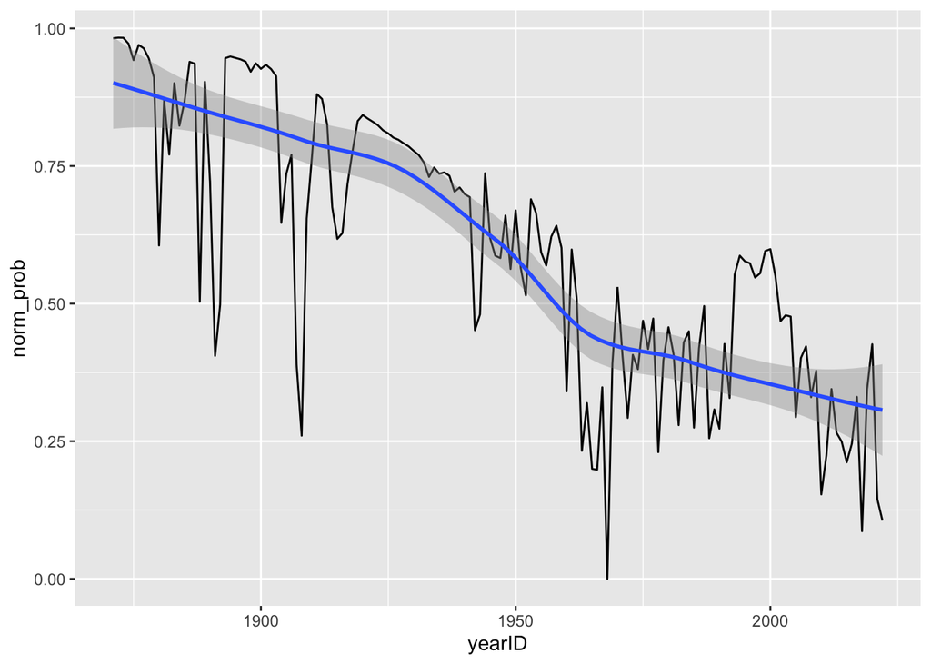

# References

Eck, D. J. (2020), “Challenging WAR and other statistics as era-adjustment tools,” *FanGraphs*.

Mi, X., Miwa, T., and Hothorn, T. (2009), “Mvtnorm: New numerical algorithm for multivariate normal probabilities,” *R Journal 1 (2009), Nr. 1*, Vienna: The R Foundation, 1, 37–39.

Schell, M. J. (2016), *Baseball’s all-time best sluggers*, Princeton University Press.